*Authors: Jan Borowski, Filip Chrzuszcz, Piotr Fic (Warsaw University of Technology)*

### Abstract

Missing observations in data sets used in machine learning models is a common and difficult problem. Most implementations of machine learning models, available in popular packages, are not prepared to deal with missing values. This requires user pre-processing of data. There are many suggestions to deal with this problem. Some solutions have been automated and are offered in publicly available packages for the R language. In our study, we tried to compare the quality of different methods of data imputation and their impact on the performance of machine learning models.  
…

### Introduction and Motivation

#### Definition of missing data

In the field of machine learning, one of the key objects is the data set. Real-world data are often incomplete, which prevents the usage of many algorithms. Before creating a machine learning model, it is essential to solve the problem of missing observations. At the beginning, clariyfing the definition of missing data is necessary. Missing data means that one or more variables have no data values in observations. This can be caused by various reasons, which we can formally define as follows:

- MCAR (Missing completely at random)  
  Values are missing completely at random if the events that lead to lack of value are independent both of observable variable and of unobservable parameters. The missing data are simply a random subset of the data. Analysis performed on MCAR data is unbiased. However, data are rarely MCAR.
- MAR (Missing at random)  
  Missingness of the values can be fully explained by complete variables. In other words, missing data are not affected by their characteristic, but are related to some or all of observed data. This is the most common assumption about missing data.
- MNAR (Missing not at random)  
  When data are missing not at random, the missingness is related to the characteristic of variable itself.

#### Techniques of dealing with missing data

In case of preparing a data set for machine learning models we can generally distinguish two approaches. The first method is **omission**. From the data set we can remove observations with at least one missing value or we can remove whole variables where missing values are present. This strategy is appropriate if the features are MCAR. However, it is frequently used also when this assumption is not met. It is also useless when the percentage of missing values is high. The second approach is **imputation**, where values are filled in the place of missing data. There are many methods of imputation, which we can divide into two groups. **Single imputation** techniques use information of one variable with missing values. Popular method is filling missings with mean, median or mode of no missing values. More advanced are predictions from regression models which are applied on the mean and covariance matrix estimated by analysis of complete cases. The main disadvantage of single imputation is treating the imputed value as true value. This method does not take into account the uncertainty of the missing value prediction. For this reason **multiple imputation** was proposed. This method imputes *k* values, which leads to creating *k* complete data sets. The analysis or model is applied on each complete data set and finally results are consolidated. This approach keeps the uncertainty about the range of values which the true value could have taken. Additionally, multiple imputation can be used in both cases of MCAR and MAR data.

#### Motivation

Various imputation techniques are implemented in different packages for the R language. Their performance is often analyzed independently and only in terms of imputation alone. Because of variety of available tools, it becomes uncertain which one package and method to use, when complete data set is needed for machine learning model. In our study we would like to examine, how methods offered by some popular packages perform on various data sets. We want to consider flexibility of these packages to deal with different data sets. The most important issue for us is the impact of performed imputation on later machine learning model performance. We are going to consider one specific type of machine learning tasks: *supervised binary classification*. Our aim is a comparison of metrics scores achieved by various models depending on chosen imputation method.

### Methodology

#### Packages and methods chosen for research

- **Mode and median**: Simple technique of filling missing values with mode (for categorical variables) and median (for continuous variables) of complete values in variable. Implemented with basic R language functions.
- **mice**: Package allows to perform multivariate imputation by chained equations (MICE), which is a type of multiple imputation. Works on data sets with both categorical and continuous variables.
- **missMDA**: Package for missing values imputation both for categorical and continuous variables. Data sets with mix variables are imputed with regularized iterative FAMD algorithm (factorial analysis for mixed data).
- **missFOREST**: Package can be used for imputation categorical and continuous data with predictions of random forest model, trained on complete observations. Package works on data with complex interactions and non-linear relations.
- **softImpute**: Package for matrix imputation with nuclear-norm regularization and soft-thresholded SVD algorithm. Works only with continuous variables.
- **VIM**: Package for visualization and imputation of missing values. In our study function for iterative robust model-based imputation (IRMI) is used.

Before imputacien datasets are prepared. Preperation are different for each dataset but always include:

1. Checking for typos and correcting them.
2. Categorical veriable are convert to lowercase when it reduce number of unique categories.
3. Removing columns if they are not containing any information (for example all observation have the same value).
4. Features like date or location are transform to help algoritm understand them (date for example is splited to three column ‘year’ , ‘day’ , ‘month’).

From prepered datasets we remove target variable and split dataset to train and test sets in proportion 4/1 respectively. Split is performed randomly and do stay the same for all types of imputation. Missing data are imputed separately for train and test set.  
First we use Mode/median inputation where every categorical varible is imputed by mode and every numeric by median. It is very simple method and it is used as base result for more complex algoritm to improve.  
SoftImpute package works only with numeric features to compere theme with othere algoritm on the same data we use SoftImput for numeric variable and mode for categorical variable. Alternativly it is possible to use SoftImpute for numeric features and different algorihtm for categorical variables, but we decided that this approach may lead to unreliable results.  
MissForest algoritm can be use on both numeric and categorical featues and is capable of performing imputation without any help of other methods.  
Inputation method from Mice package also can be run on all types of data.  
Iterative Robust Model-Based Imputation method form VIM package can impute all types of data. This method additionally create new columns with informacion whether observation was imputed or not. We decidet to do not use these columns, because other methods do not create them.  
Last method which we covered is missMDA which also can be use to imput numeric and categorical features.  
After imputation we add back target varibale to both sets.

To make prediction we use ‘classif.rpart’ method form mlr packege. It is an inplementation of a Decision Tree algorithm, which is capable of working with categorical data, so that we did not have to additionaly encode it. To evaluate imputation methods, classifier was trained on train set and tested on test set. In this experiment we have skipped cross-validation step. For model evaluation we used 4 diffrent metrics: accuracy AUC,precison and recall. We found precision and recall as most valuable for us, as some datasets were quite unbalanced.

### Results

After the long and tedious process of data imputation it is finally time to evaluate our methods of imputation. Methods were trained and tested on 11 datasets and evaluated strictly using these 4 methods mentioned earlier. Before score analysis it is worth mentioning that all algorithms were tested with basic parametres, so there is certainly some room for improvementm but for now we decided to leave these scores as they are.

Scores of imputation methods

| Method | acc | auc | precision | recall |
| --- | --- | --- | --- | --- |
| forest | 0.82 | 0.81 | 0.78 | 0.75 |
| irmi | 0.82 | 0.82 | 0.77 | 0.78 |
| MDA | 0.74 | 0.73 | 0.68 | 0.67 |
| median | 0.81 | 0.75 | 0.76 | 0.73 |
| mice | 0.83 | 0.78 | 0.80 | 0.77 |
| softImpute | 0.79 | 0.80 | 0.70 | 0.62 |

Our experiment definately did not find out the best imputation algoriithm, but we can derive some interesting conclusions from it. First of all, we are going to treat median imputation as kind of a baseline for our algorithms. Suprisngly it seems to perform quite well, amongst the others, often quite sophisticated methods. It achieved over 80% of accuracy on average. However, it is hard to decide whether it is a high score or not, because we are only able to compare algorithms between the others. To say anything more meanigful about our methods we shall look at the distribution of the scores in order to make a better analysis of performance.

#### ROC AUC score

As mentioned earlier we decided to use a few metrics to compare algorithms. One of it is ROC AUC score. It is a measure which caluclates TPR (which is ratio beetwen our predicted positive examples over overall amount of positive examples) and FPR (which is ratio beetwen false positives and all negative examples). Next TPR and FPR are evaluated at different thershold values and than we have something called ROC curve. Our measure is simply the area under that curve. Obviously the maximum of that score is 1. ROC AUC is also quite good for working with imbalanced sets, which may be useful for us, because we had to deal with such in our experiment.

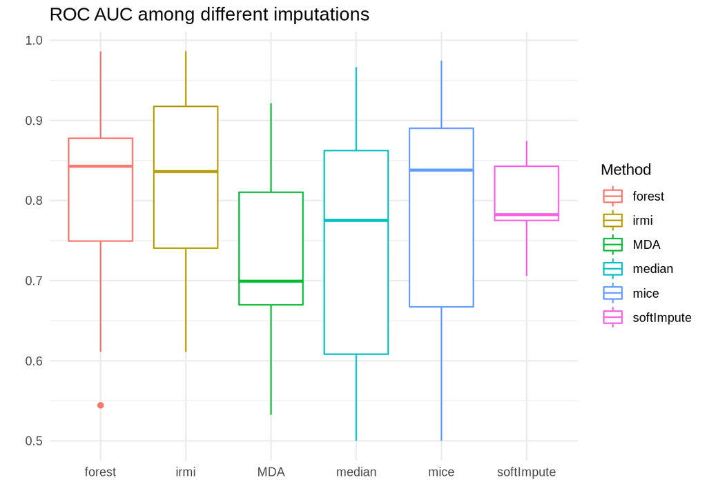

Taking a brief look at the distributions of the scores it is clear that median is not so good. Its scores seems to vary the most among datasets, which is not something we ideally want. Also it is worth noting that unfortunately missMDA achieved the worse score and also was the most problematic imputation technic from which we tested. It did not manage the perform its imputations on 5 out of 11 datasets, which clearly disqualify this method from everyday usage. Also softimpute had problem with working on all sets, albeit it managed to perform quite decent scores. On the other end are VIM irmi, missFOREST and Mice. All of these three packages managed to make imputations on all sets, and achieved good scores.

#### Precision and recall

Moving further into score analysis we need to focus on two undeniably important parameters, which are precision and recall. We can understand recall as an ability of a model to find all the relevant cases within a dataset, while precision expresses the proportion of the data our model says was relevant actually were relevant. Ideally we would like to make both of these metrics as high, as possible, which is of course not so possible. Instead we can focus on one of these two depending what problem we are solving. However, in our experiment we are not capable to say which metric is more important for us, so we can simply compare them, and on that basis say something about our methods.

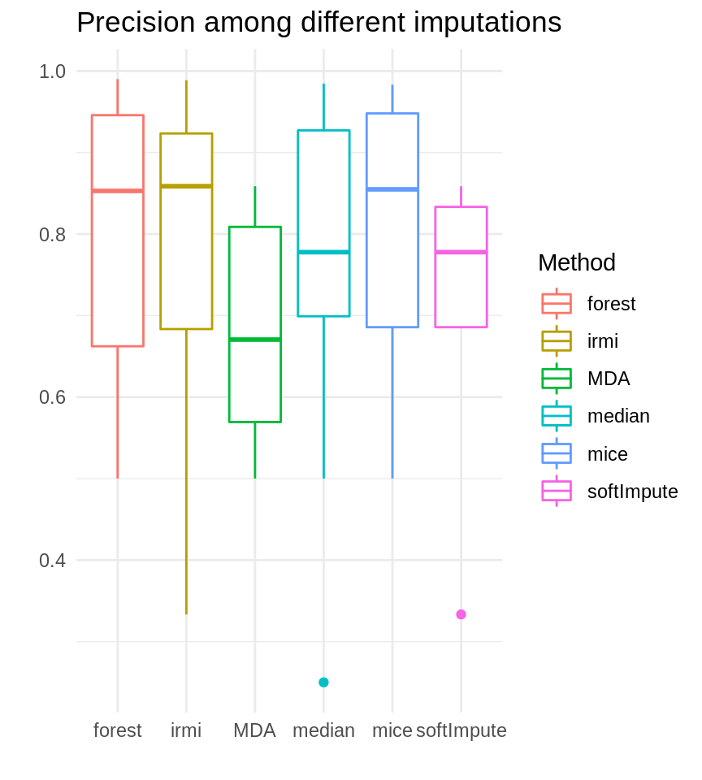

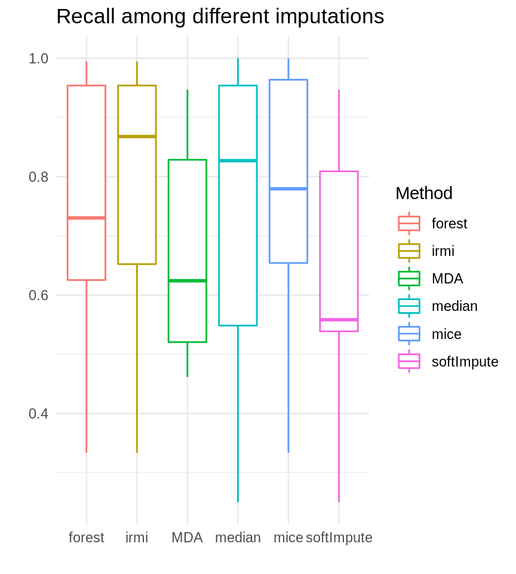

#### Time of imputations

The last topic we wish to consider in our analysis section is the time of imputations. It is quite significant, because even the best imputation may become redundant if it has too long working time.

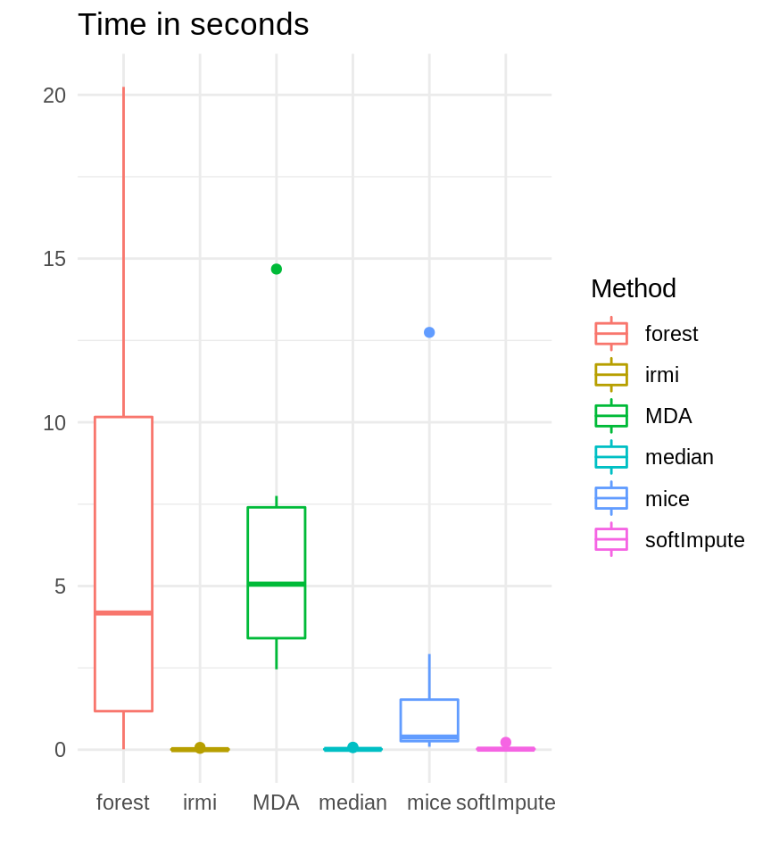

We can divide our algorithms into two groups. In the first one, there are:  
- VIM irmi  
- Median  
- Mice  
- SoftImpute  
This group is simply characterised by very low time need to peroform the imputation. Second group consists of:  
- missFOREST  
- missMDA  
Algorithms from that group had that quite high, which may be unacceptable while working with huge datasets.